# Notebook 1 — Préparation et nettoyage des données

## Projet : Étude de marché internationale — La Poule qui Chante

**Objectif :** Identifier les pays les plus propices à l'exportation de volailles françaises.

**Ce notebook couvre :**

- Chargement des 7 sources de données
- Exploration et diagnostic qualité
- Nettoyage et harmonisation
- Fusion en un dataset analytique unique
- Sauvegarde pour le Notebook 2 (ACP + Clustering)

## 0. Imports et configuration

```python
import pandas as pd
import numpy as np
import matplotlib.pyplot as plt
import matplotlib.ticker as mtick
import seaborn as sns
import warnings
import os

warnings.filterwarnings('ignore')

# Style graphique
plt.rcParams['figure.figsize'] = (12, 5)
plt.rcParams['axes.titlesize'] = 13
plt.rcParams['axes.labelsize'] = 11
sns.set_style('whitegrid')

# Dossier de sortie
os.makedirs('outputs', exist_ok=True)

print('Imports OK')
print(f'   pandas  : {pd.__version__}')
print(f'   numpy   : {np.__version__}')
```

```
Imports OK
   pandas  : 2.2.2
   numpy   : 1.26.4
```

## 1. Chargement des données brutes

Nous chargeons les **7 fichiers sources** indépendamment avant toute transformation.

| # | Fichier | Source | Variable extraite | Dimension PESTEL |
| --- | --- | --- | --- | --- |
| 1 | `population.csv` | FAOSTAT | Population totale | Social |
| 2 | `Stat_macro_Indicateurs.csv` | FAOSTAT | PIB/habitant | Économique |
| 3 | `BilansAlimentaires.csv` | FAOSTAT | Volaille kg/hab, Protéines | Social |
| 4 | `stabilite.csv` | BM WGI | Stabilité politique | Politique |
| 5 | `import_volaille.csv` | FAOSTAT | Importations volaille | Économique |
| 6 | `urbanisation.csv` | FAOSTAT | Taux durbanisation | Social |
| 7 | `legal.csv` | QoG / BM WGI | Contrôle de la corruption | Légal |

# 1. Chargement des données brutes

Nous chargeons les **7 fichiers sources** indépendamment avant toute transformation.

[output not shown]

```python
# ── 1.1 Population (FAOSTAT) ─────────────────────────────────────────────────
population = pd.read_csv('D:/dataAnalyst/Projet11/travail/population.csv', encoding='utf-8')
print(f'Population brut   : {population.shape[0]:>6} lignes × {population.shape[1]} colonnes')

# ── 1.2 PIB / Macro (FAOSTAT) ────────────────────────────────────────────────
statistiques = pd.read_csv('D:/dataAnalyst/Projet11/travail/Stat_macro_Indicateurs.csv', encoding='utf-8')
print(f'Macro brut        : {statistiques.shape[0]:>6} lignes × {statistiques.shape[1]} colonnes')

# ── 1.3 Bilans alimentaires (FAOSTAT) ────────────────────────────────────────
# Fichier volumineux : on charge uniquement les colonnes utiles
cols_bilans = ['Zone', 'Produit', 'Élément', 'Y2021']
bilan_alimentaire = pd.read_csv(
    'D:/dataAnalyst/Projet11/travail/BilansAlimentaires.csv',
    encoding='utf-8',
    usecols=cols_bilans
)
print(f'Bilans brut       : {bilan_alimentaire.shape[0]:>6} lignes × {bilan_alimentaire.shape[1]} colonnes')

# ── 1.4 Stabilité politique (Banque Mondiale / WGI) ──────────────────────────
stab_politique = pd.read_csv('D:/dataAnalyst/Projet11/travail/stabilite.csv', skiprows=4)
print(f'WGI brut          : {stab_politique.shape[0]:>6} lignes × {stab_politique.shape[1]} colonnes')

# ── 1.5 Importations volaille (FAOSTAT) ──────────────────────────────────────
# Source PESTEL — dimension Économique
# Contient les importations de toutes les catégories de viandes de volaille par pays, 2021
import_volaille = pd.read_csv(
    'D:/dataAnalyst/Projet11/travail/import_volaille.csv',
    encoding='utf-8'
)
print(f'Importations brut      : {import_volaille.shape[0]:>6} lignes × {import_volaille.shape[1]} colonnes')

# ── 1.6 Urbanisation (FAOSTAT) ───────────────────────────────────────────────
# Source PESTEL — dimension Social
# Contient population urbaine et population totale par pays, 2021
urbanisation = pd.read_csv(
    'D:/dataAnalyst/Projet11/travail/urbanisation.csv',
    encoding='utf-8'
)
print(f'Urbanisation brut      : {urbanisation.shape[0]:>6} lignes × {urbanisation.shape[1]} colonnes')

# ── 1.7 Contrôle de la corruption (QoG Institute / BM WGI) ──────────────────
# Source PESTEL — dimension Légal
# Le fichier WGI de la Banque Mondiale étant inaccessible, nous utilisons le
# Quality of Government Standard Dataset (Université de Göteborg) qui redistribue
# les mêmes données WGI. Indicateur retenu : wbgi_cce (Control of Corruption Estimate)
legal = pd.read_csv(
    'D:/dataAnalyst/Projet11/travail/legal.csv',
    encoding='utf-8',
    low_memory=False
)
print(f'QoG (corruption - légalité) brut  : {legal.shape[0]:>6} lignes × {legal.shape[1]} colonnes')
```

```
Population brut   :   1385 lignes × 461 colonnes
Macro brut        :  16642 lignes × 173 colonnes
Bilans brut       : 373670 lignes × 4 colonnes
WGI brut          :    266 lignes × 71 colonnes
Importations brut      :   1321 lignes × 15 colonnes
Urbanisation brut      :    468 lignes × 15 colonnes
QoG (corruption - légalité) brut  :    194 lignes × 1487 colonnes
```

## 2. Exploration et diagnostic qualité

Avant tout nettoyage, nous explorons chaque source pour comprendre sa structure et identifier les problèmes potentiels.

```python
# ── 2.1 Population ───────────────────────────────────────────────────────────
print('=== POPULATION ===')
print(f'Pays uniques      : {population["Zone"].nunique()}')
print(f'Éléments          : {population["Élément"].unique()}')
print(f'Années disponibles: Y2010 → Y2025')
print(f'Valeurs manquantes Y2021 : {population["Y2021"].isna().sum()}')
population[['Zone','Élément','Y2021']].head(3)
```

```
=== POPULATION ===
Pays uniques      : 279
Éléments          : ['Population totale' 'Hommes' 'Femmes' 'Population rurale'
 'Population urbaine']
Années disponibles: Y2010 → Y2025
Valeurs manquantes Y2021 : 45
```

|  | Zone | Élément | Y2021 |
| --- | --- | --- | --- |
| 0 | Afghanistan | Population totale | 40000.412 |
| 1 | Afghanistan | Hommes | 20186.456 |
| 2 | Afghanistan | Femmes | 19813.956 |

```python
# ── 2.2 PIB / Macro ──────────────────────────────────────────────────────────
print('=== MACRO / PIB ===')
print(f'Pays uniques      : {statistiques["Zone"].nunique()}')
print(f'Produits          : {statistiques["Produit"].nunique()} types')
print(f'Éléments          : {statistiques["Élément"].nunique()} types')
print(f'\nProduits disponibles :')
for p in statistiques['Produit'].unique():
    print(f'  - {p}')
print(f'\nÉléments disponibles :')
for e in statistiques['Élément'].unique()[:5]:
    print(f'  - {e}')
```

```
=== MACRO / PIB ===
Pays uniques      : 252
Produits          : 11 types
Éléments          : 20 types

Produits disponibles :
  - Produit Intérieur Brut
  - Formation brute de capital fixe
  - Valeur ajoutée (agriculture, sylviculture et pêche)
  - Valeur ajoutée (Industrie manufacturière)
  - Revenu national brut
  - Valeur ajoutée (Fabrication de produits alimentaires, boissons et de produits à base de tabac)
  - Valeur ajoutée (Fabrication de produits alimentaires et boissons)
  - Valeur ajoutée (Fabrication de produits à base de tabac)
  - Production brute (Agriculture, Sylviculture et Pêche)
  - Valeur ajoutée (Agriculture)
  - Production brute (Agriculture)

Éléments disponibles :
  - Valeur en devise locale standardisée
  - Valeur US$
  - Valeur US$ par habitant
  - Valeur en devise locale standardisée, aux prix de 2015
  - Valeur US$ par habitant, aux prix de 2015
```

```python
# ── 2.3 Bilans alimentaires ───────────────────────────────────────────────────
print('=== BILANS ALIMENTAIRES ===')
print(f'Pays uniques      : {bilan_alimentaire["Zone"].nunique()}')
print(f'Produits uniques  : {bilan_alimentaire["Produit"].nunique()}')

# Vérifier la présence de la volaille
produits_volaille = bilan_alimentaire[bilan_alimentaire['Produit'].str.contains('Volaille|Volailles', na=False)]['Produit'].unique()
print(f'Produits volaille : {produits_volaille}')

print(f'\nÉléments disponibles :')
for e in bilan_alimentaire['Élément'].unique():
    print(f'  - {e}')
```

```
=== BILANS ALIMENTAIRES ===
Pays uniques      : 213
Produits uniques  : 119
Produits volaille : ['Viande de Volailles']

Éléments disponibles :
  - Population totale
  - Disponibilité alimentaire (Kcal/personne/jour)
  - Disponibilité alimentaire (Kcal)
  - Disponibilité de protéines en quantité (g/personne/jour)
  - Disponibilité de protéines en quantité (t)
  - Disponibilité de matière grasse en quantité (g/personne/jour)
  - Disponibilité de matière grasse en quantité (t)
  - Production
  - Importations - quantité
  - Variation de stock
  - Exportations - quantité
  - Disponibilité intérieure
  - Aliments pour animaux
  - Semences
  - Pertes
  - Traitement
  - Autres utilisations (non alimentaire)
  - Résidus
  - Nourriture
  - Disponibilité alimentaire en quantité (kg/personne/an)
  - Alimentation pour touristes
```

```python
# ── 2.4 WGI Stabilité politique ───────────────────────────────────────────────
print('=== WGI — STABILITÉ POLITIQUE ===')
print(f'Pays totaux       : {len(stab_politique)}')
print(f'Années disponibles: 1996 → 2023')
print(f'Données 2021      : {stab_politique["2021"].notna().sum()} pays renseignés')
print(f'Valeurs manquantes: {stab_politique["2021"].isna().sum()} pays sans données')
print(f'\nÉtendue de l\'indicateur :')
vals = pd.to_numeric(stab_politique['2021'], errors='coerce').dropna()
print(f'  Min : {vals.min():.2f} | Max : {vals.max():.2f} | Moy : {vals.mean():.2f}')
```

```
=== WGI — STABILITÉ POLITIQUE ===
Pays totaux       : 266
Années disponibles: 1996 → 2023
Données 2021      : 205 pays renseignés
Valeurs manquantes: 61 pays sans données

Étendue de l'indicateur :
  Min : -2.73 | Max : 1.88 | Moy : -0.04
```

```python
# ── 2.5 Exploration des importations volaille
print('=== Importations volaille (FAOSTAT) ===')
print(f'Shape : {import_volaille.shape}')
print(f'Pays  : {import_volaille["Zone"].nunique()}')
print(f'Produits : {import_volaille["Produit"].nunique()}')
print()
print('Produits disponibles :')
for p in import_volaille['Produit'].unique():
    print(f'  - {p}')
print()
print('NaN dans Valeur :', import_volaille['Valeur'].isna().sum())
print()
# Top 10 importateurs (toutes catégories agrégées)
top_imp = import_volaille.groupby('Zone')['Valeur'].sum().sort_values(ascending=False).head(10)
print('Top 10 importateurs (tonnes) :')
print(top_imp.to_string())
```

```
=== Importations volaille (FAOSTAT) ===
Shape : (1321, 15)
Pays  : 200
Produits : 11

Produits disponibles :
  - Préparations à base de viande de volaille
  - Viande, canard, fraîche ou réfrigérée
  - Viande, dinde, fraîche ou réfrigérée
  - Viande, oie, fraîche ou réfrigérée
  - Viande, poulet, fraîche ou réfrigérée
  - Viande de Volailles
  - Abats et foies comestibles de canard, frais, réfrigérés ou congelés
  - Abats et foies comestibles de poulets et de pintades, frais, réfrigérés ou congelés
  - Foie gras, préparations
  - Abats et foies comestibles d'oie, frais, réfrigérés ou congelés
  - Viande, pigeons et autres volatiles n.a.c., fraîche, réfrigérée ou congelée

NaN dans Valeur : 0

Top 10 importateurs (tonnes) :
Zone
Monde                                                  37379826.73
Chine                                                   4170511.15
Chine, continentale                                     2960262.92
Japon                                                   2408053.22
Mexique                                                 2392956.16
Pays-Bas (Royaume des)                                  1799703.68
Émirats arabes unis                                     1735693.21
Allemagne                                               1669037.62
Royaume-Uni de Grande-Bretagne et d'Irlande du Nord     1607959.68
France                                                  1281282.54
```

```python
# ── 2.6 Exploration de l'urbanisation
print('=== Urbanisation (FAOSTAT) ===')
print(f'Shape  : {urbanisation.shape}')
print(f'Pays   : {urbanisation["Zone"].nunique()}')
print(f'Éléments : {urbanisation["Élément"].unique()}')
print()
# Calculer taux d'urbanisation pour aperçu
_pop_urb = urbanisation[urbanisation['Élément']=='Population urbaine'][['Zone','Valeur']]
_pop_tot = urbanisation[urbanisation['Élément']=='Population totale'][['Zone','Valeur']]
_urb = _pop_urb.merge(_pop_tot, on='Zone', suffixes=('_urb','_tot'))
_urb['taux'] = (_urb['Valeur_urb'] / _urb['Valeur_tot'] * 100).round(1)
print('NaN taux urbanisation :', _urb['taux'].isna().sum())
print()
print('Exemples :')
print(_urb[_urb['Zone'].isin(['France','Allemagne','Chine','Inde','États-Unis d\'Amérique'])]
      [['Zone','taux']].to_string(index=False))
```

```
=== Urbanisation (FAOSTAT) ===
Shape  : (468, 15)
Pays   : 236
Éléments : ['Population totale' 'Population urbaine']

NaN taux urbanisation : 0

Exemples :
                 Zone  taux
            Allemagne  76.5
                Chine  63.1
États-Unis d'Amérique  81.3
               France  81.1
                 Inde  35.0
```

```python
# ── 2.7 Exploration du fichier QoG (legal)
print('=== Contrôle de la corruption (QoG / WGI) ===')
print(f'Shape  : {legal.shape}')
print(f'Pays   : {legal["cname"].nunique()}')
print()
# Extraire uniquement les colonnes WGI
wgi_cols = [c for c in legal.columns if 'wbgi' in c]
print(f'Indicateurs WGI disponibles ({len(wgi_cols)}) : {wgi_cols}')
print()
print('Statistiques wbgi_cce (Contrôle corruption) :')
print(legal['wbgi_cce'].describe().round(3))
print()
print('NaN wbgi_cce :', legal['wbgi_cce'].isna().sum())
print()
print('Top 5 pays les moins corrompus :')
print(legal[['cname','wbgi_cce']].dropna()
      .sort_values('wbgi_cce', ascending=False).head().to_string(index=False))
print()
print('Top 5 pays les plus corrompus :')
print(legal[['cname','wbgi_cce']].dropna()
      .sort_values('wbgi_cce').head().to_string(index=False))
```

```
=== Contrôle de la corruption (QoG / WGI) ===
Shape  : (194, 1487)
Pays   : 194

Indicateurs WGI disponibles (18) : ['wbgi_cce', 'wbgi_ccn', 'wbgi_ccs', 'wbgi_gee', 'wbgi_gen', 'wbgi_ges', 'wbgi_pve', 'wbgi_pvn', 'wbgi_pvs', 'wbgi_rle', 'wbgi_rln', 'wbgi_rls', 'wbgi_rqe', 'wbgi_rqn', 'wbgi_rqs', 'wbgi_vae', 'wbgi_van', 'wbgi_vas']

Statistiques wbgi_cce (Contrôle corruption) :
count    192.000
mean      -0.042
std        0.991
min       -1.861
25%       -0.774
50%       -0.227
75%        0.651
max        2.302
Name: wbgi_cce, dtype: float64

NaN wbgi_cce : 2

Top 5 pays les moins corrompus :
      cname  wbgi_cce
    Denmark  2.302238
    Finland  2.189470
Switzerland  2.094943
New Zealand  2.082293
     Norway  2.033210

Top 5 pays les plus corrompus :
                                      cname  wbgi_cce
                                South Sudan -1.861122
                 Syrian Arab Republic (the) -1.792435
                                      Yemen -1.666280
Korea (the Democratic People's Republic of) -1.651760
         Venezuela (Bolivarian Republic of) -1.603038
```

### 2.8 Visualisation des valeurs manquantes par source

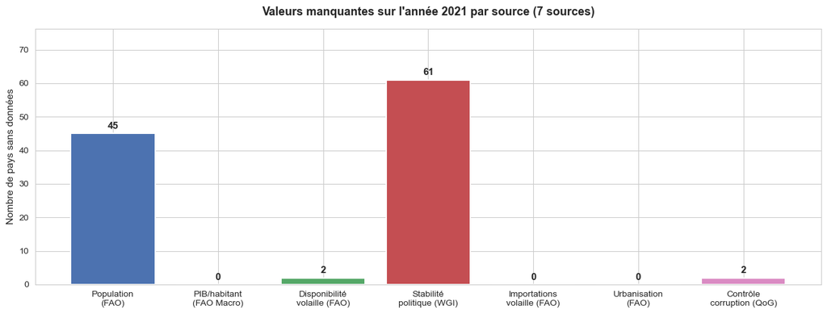

```
Graphique sauvegardé
```

```python
# Résumé des valeurs manquantes sur Y2021 pour chaque source
sources = {
    'Population\n(FAO)': population['Y2021'].isna().sum(),
    'PIB/habitant\n(FAO Macro)': statistiques[
        (statistiques['Produit'] == 'Produit Intérieur Brut') &
        (statistiques['Élément'] == 'Valeur US$ par habitant')
    ]['Y2021'].isna().sum(),
    'Disponibilité\nvolaille (FAO)': bilan_alimentaire[
        (bilan_alimentaire['Produit'] == 'Viande de Volailles') &
        (bilan_alimentaire['Élément'] == 'Disponibilité alimentaire en quantité (kg/personne/an)')
    ]['Y2021'].isna().sum(),
    'Stabilité\npolitique (WGI)': stab_politique['2021'].isna().sum(),
    # ── Nouvelles sources ──────────────────────────────────────────────────────
    'Importations\nvolaille (FAO)': import_volaille['Valeur'].isna().sum(),
    'Urbanisation\n(FAO)': urbanisation[
        urbanisation['Élément'] == 'Population urbaine'
    ]['Valeur'].isna().sum(),
    'Contrôle\ncorruption (QoG)': legal['wbgi_cce'].isna().sum(),
}

couleurs = [
    '#4C72B0',  # Population
    '#DD8452',  # PIB
    '#55A868',  # Volaille
    '#C44E52',  # Stabilité
    '#8172B2',  # Importations
    '#937860',  # Urbanisation
    '#DA8BC3',  # Corruption
]

fig, ax = plt.subplots(figsize=(13, 5))
bars = ax.bar(sources.keys(), sources.values(), color=couleurs,
              edgecolor='white', linewidth=1.5)
ax.bar_label(bars, fmt='%d', padding=3, fontsize=11, fontweight='bold')
ax.set_title('Valeurs manquantes sur l\'année 2021 par source (7 sources)',
             fontweight='bold', pad=15)
ax.set_ylabel('Nombre de pays sans données')
ax.set_ylim(0, max(sources.values()) * 1.25 if max(sources.values()) > 0 else 10)
plt.tight_layout()
plt.savefig('outputs/01_valeurs_manquantes.png', dpi=150, bbox_inches='tight')
plt.show()
print('Graphique sauvegardé')
```

## 3. Nettoyage et extraction par source

Pour chaque source, nous :

1. Filtrons sur l'année 2021
2. Sélectionnons les éléments pertinents
3. Renommons les colonnes de façon homogène
4. Supprimons les agrégats régionaux (Monde, Afrique...)

```python
# ── 3.1 Population totale 2021 (en millions d'habitants) ─────────────────────
pop_nettoye = (
    population[population['Élément'] == 'Population totale']
    [['Zone', 'Y2021']]
    .copy()
    .rename(columns={'Zone': 'pays_fao', 'Y2021': 'population_M'})
)

# Conversion : milliers → millions
pop_nettoye['population_M'] = pd.to_numeric(pop_nettoye['population_M'], errors='coerce') / 1000
pop_nettoye = pop_nettoye.dropna()

print(f'Population nettoyée : {len(pop_nettoye)} pays')
print(f'Unité : millions d\'habitants')
print(f'Min : {pop_nettoye["population_M"].min():.3f} M | Max : {pop_nettoye["population_M"].max():.1f} M')
pop_nettoye.head(10)
```

```
Population nettoyée : 268 pays
Unité : millions d'habitants
Min : 0.002 M | Max : 7954.4 M
```

|  | pays_fao | population_M |
| --- | --- | --- |
| 0 | Afghanistan | 40.000412 |
| 5 | Afrique du Sud | 61.502603 |
| 10 | Albanie | 2.849635 |
| 15 | Algérie | 44.761099 |
| 20 | Allemagne | 83.697083 |
| 25 | Andorre | 0.078364 |
| 30 | Angola | 34.532429 |
| 35 | Anguilla | 0.014475 |
| 40 | Antigua-et-Barbuda | 0.092349 |
| 50 | Arabie saoudite | 31.328375 |

```python
# ── 3.2 PIB par habitant 2021 (en USD courants) ───────────────────────────────
pib_nettoye = (
    statistiques[
        (statistiques['Produit'] == 'Produit Intérieur Brut') &
        (statistiques['Élément'] == 'Valeur US$ par habitant')
    ]
    [['Zone', 'Y2021']]
    .copy()
    .rename(columns={'Zone': 'pays_fao', 'Y2021': 'pib_hab_usd'})
)

pib_nettoye['pib_hab_usd'] = pd.to_numeric(pib_nettoye['pib_hab_usd'], errors='coerce')
pib_nettoye = pib_nettoye.dropna()

# Vérifier l'absence de doublons (un seul PIB par pays)
doublons = pib_nettoye['pays_fao'].duplicated().sum()
print(f'PIB nettoyé   : {len(pib_nettoye)} pays')
print(f'Doublons      : {doublons}')
print(f'Min : {pib_nettoye["pib_hab_usd"].min():.0f} USD | Max : {pib_nettoye["pib_hab_usd"].max():,.0f} USD')
pib_nettoye.head(3)
```

```
PIB nettoyé   : 244 pays
Doublons      : 0
Min : 243 USD | Max : 223,823 USD
```

|  | pays_fao | pib_hab_usd |
| --- | --- | --- |
| 2 | Afghanistan | 379.019110 |
| 57 | Afrique du Sud | 6830.894725 |
| 152 | Albanie | 6292.230758 |

```python
# ── 3.3 Disponibilité volaille 2021 ──────────────────────────────────────────
elements_volaille = [
    'Disponibilité alimentaire en quantité (kg/personne/an)',
    'Disponibilité de protéines en quantité (g/personne/jour)'
]

vol_nettoye = (
    bilan_alimentaire[
        (bilan_alimentaire['Produit'] == 'Viande de Volailles') &
        (bilan_alimentaire['Élément'].isin(elements_volaille))
    ]
    [['Zone', 'Élément', 'Y2021']]
    .copy()
)

vol_nettoye['Y2021'] = pd.to_numeric(vol_nettoye['Y2021'], errors='coerce')
vol_nettoye = vol_nettoye.dropna()

# Pivoter : une ligne par pays, une colonne par élément
vol_nettoye = vol_nettoye.pivot_table(index='Zone', columns='Élément', values='Y2021').reset_index()
vol_nettoye.columns = ['pays_fao', 'proteines_g', 'volaille_kg_hab']
vol_nettoye = vol_nettoye.dropna()

print(f'Volaille nettoyée : {len(vol_nettoye)} pays')
print(f'kg/pers/an — Min : {vol_nettoye["volaille_kg_hab"].min():.2f} | Max : {vol_nettoye["volaille_kg_hab"].max():.2f}')
vol_nettoye.head(3)
```

```
Volaille nettoyée : 211 pays
kg/pers/an — Min : 0.18 | Max : 54.80
```

|  | pays_fao | proteines_g | volaille_kg_hab |
| --- | --- | --- | --- |
| 0 | Afghanistan | 1.52 | 0.68 |
| 1 | Afrique | 6.98 | 3.16 |
| 2 | Afrique australe | 32.52 | 14.70 |

```python
# ── 3.4 Stabilité politique WGI 2021 ─────────────────────────────────────────
wgi_nettoye = (
    stab_politique[['Country Name', '2021']]
    .copy()
    .rename(columns={'Country Name': 'pays_wgi', '2021': 'stabilite_politique'})
)

wgi_nettoye['stabilite_politique'] = pd.to_numeric(wgi_nettoye['stabilite_politique'], errors='coerce')
wgi_nettoye = wgi_nettoye.dropna()

print(f'WGI nettoyé   : {len(wgi_nettoye)} pays')
print(f'Étendue : {wgi_nettoye["stabilite_politique"].min():.2f} → {wgi_nettoye["stabilite_politique"].max():.2f}')
print('(Indice WGI : -3 = très instable, +3 = très stable)')
wgi_nettoye.head(3)
```

```
WGI nettoyé   : 205 pays
Étendue : -2.73 → 1.88
(Indice WGI : -3 = très instable, +3 = très stable)
```

|  | pays_wgi | stabilite_politique |
| --- | --- | --- |
| 0 | Aruba | 1.431727 |
| 2 | Afghanistan | -2.518676 |
| 4 | Angola | -0.710481 |

```python
# ── 3.5 Importations volaille 2021 (en tonnes) ───────────────────────────────
# On agrège toutes les catégories de viandes de volaille par pays
# et on exclut les agrégats régionaux (Monde, Afrique, etc.)

# Liste des agrégats FAO à exclure
agregats_fao = [
    'Monde', 'Afrique', 'Amériques', 'Asie', 'Europe', 'Océanie',
    'Afrique subsaharienne', 'Afrique du Nord', 'Asie orientale',
    'Asie du Sud', 'Asie du Sud-Est', 'Asie centrale',
    'Amérique latine et Caraïbes', 'Amérique du Nord',
    'Europe occidentale', 'Europe orientale', 'Moyen-Orient',
    'Pays moins avancés', 'Pays en développement',
    'Pays à faible revenu et à déficit vivrier',
]

import_nettoye = (
    import_volaille[~import_volaille['Zone'].isin(agregats_fao)]
    .groupby('Zone')['Valeur']
    .sum()
    .reset_index()
    .rename(columns={'Zone': 'pays_fao', 'Valeur': 'import_volaille_t'})
)
import_nettoye['import_volaille_t'] = import_nettoye['import_volaille_t'].round(2)

print(f'Importations nettoyées : {len(import_nettoye)} pays')
print(f'NaN : {import_nettoye["import_volaille_t"].isna().sum()}')
print()
print('Top 10 importateurs :')
print(import_nettoye.sort_values('import_volaille_t', ascending=False)
      .head(10).to_string(index=False))
```

```
Importations nettoyées : 199 pays
NaN : 0

Top 10 importateurs :
                                           pays_fao  import_volaille_t
                                              Chine         4170511.15
                                Chine, continentale         2960262.92
                                              Japon         2408053.22
                                            Mexique         2392956.16
                             Pays-Bas (Royaume des)         1799703.68
                                Émirats arabes unis         1735693.21
                                          Allemagne         1669037.62
Royaume-Uni de Grande-Bretagne et d'Irlande du Nord         1607959.68
                                             France         1281282.54
                                    Arabie saoudite         1258524.29
```

```python
# ── 3.6 Taux d'urbanisation 2021 (%) ─────────────────────────────────────────
# Calcul : population urbaine / population totale × 100

_pop_urb = (urbanisation[urbanisation['Élément'] == 'Population urbaine']
            [['Zone', 'Valeur']]
            .rename(columns={'Valeur': 'pop_urbaine'}))

_pop_tot = (urbanisation[urbanisation['Élément'] == 'Population totale']
            [['Zone', 'Valeur']]
            .rename(columns={'Valeur': 'pop_totale'}))

urb_nettoye = _pop_urb.merge(_pop_tot, on='Zone')
urb_nettoye['taux_urbanisation'] = (
    urb_nettoye['pop_urbaine'] / urb_nettoye['pop_totale'] * 100
).round(2)
urb_nettoye = urb_nettoye[['Zone', 'taux_urbanisation']].rename(columns={'Zone': 'pays_fao'})

print(f'Urbanisation nettoyée : {len(urb_nettoye)} pays')
print(f'NaN : {urb_nettoye["taux_urbanisation"].isna().sum()}')
print()
print('Statistiques descriptives :')
print(urb_nettoye['taux_urbanisation'].describe().round(2))
```

```
Urbanisation nettoyée : 232 pays
NaN : 0

Statistiques descriptives :
count    232.00
mean      62.66
std       25.65
min        0.00
25%       42.54
50%       64.99
75%       82.12
max      115.32
Name: taux_urbanisation, dtype: float64
```

```python
# ── 3.7 Contrôle de la corruption WGI 2021 ───────────────────────────────────
# Source : QoG Standard Dataset (Université de Göteborg)
# La Banque Mondiale distribue les mêmes données via www.govindicators.org
# Indicateur wbgi_cce : Control of Corruption Estimate (échelle -2.5 à +2.5)
# Valeur positive = pays peu corrompu / valeur négative = pays corrompu

corr_nettoye = (legal[['cname', 'wbgi_cce']]
                .rename(columns={'cname': 'pays', 'wbgi_cce': 'controle_corruption'})
                .dropna(subset=['controle_corruption']))

print(f'Corruption nettoyée : {len(corr_nettoye)} pays')
print(f'NaN : {corr_nettoye["controle_corruption"].isna().sum()}')
print()
print('Statistiques descriptives :')
print(corr_nettoye['controle_corruption'].describe().round(3))
print()
print('Pays les moins corrompus (Top 5) :')
print(corr_nettoye.sort_values('controle_corruption', ascending=False)
      .head().to_string(index=False))
```

```
Corruption nettoyée : 192 pays
NaN : 0

Statistiques descriptives :
count    192.000
mean      -0.042
std        0.991
min       -1.861
25%       -0.774
50%       -0.227
75%        0.651
max        2.302
Name: controle_corruption, dtype: float64

Pays les moins corrompus (Top 5) :
       pays  controle_corruption
    Denmark             2.302238
    Finland             2.189470
Switzerland             2.094943
New Zealand             2.082293
     Norway             2.033210
```

## 4. Harmonisation des noms de pays

**Problème :** Les fichiers FAO utilisent des noms de pays en **français** (ex : "Allemagne"), tandis que les données WGI utilisent des noms en **anglais** avec parfois des conventions différentes (ex : "Korea, Rep.").

**Solution :** Nous construisons une table de correspondance exhaustive `FAO (français) → WGI (anglais Banque Mondiale)` qui servira de clé de jointure unique.

```python
# ── Table 1 : FAO (français) → WGI (anglais Banque Mondiale) ─────────────────
fao_to_wgi = {
    # Europe occidentale
    "Allemagne":                          "Germany",
    "Autriche":                           "Austria",
    "Belgique":                           "Belgium",
    "Chypre":                             "Cyprus",
    "Danemark":                           "Denmark",
    "Espagne":                            "Spain",
    "États-Unis d'Amérique":              "United States",
    "Finlande":                           "Finland",
    "France":                             "France",
    "Grèce":                              "Greece",
    "Irlande":                            "Ireland",
    "Italie":                             "Italy",
    "Luxembourg":                         "Luxembourg",
    "Norvège":                            "Norway",
    "Pays-Bas":                           "Netherlands",
    "Pays-Bas (Royaume des)":             "Netherlands",
    "Portugal":                           "Portugal",
    "Royaume-Uni":                        "United Kingdom",
    "Royaume-Uni de Grande-Bretagne et d'Irlande du Nord": "United Kingdom",
    "Suède":                              "Sweden",
    "Suisse":                             "Switzerland",
    # Europe orientale
    "Albanie":                            "Albania",
    "Bosnie-Herzégovine":                 "Bosnia and Herzegovina",
    "Bulgarie":                           "Bulgaria",
    "Croatie":                            "Croatia",
    "Estonie":                            "Estonia",
    "Fédération de Russie":               "Russia",
    "Hongrie":                            "Hungary",
    "Lituanie":                           "Lithuania",
    "Pologne":                            "Poland",
    "Roumanie":                           "Romania",
    "Serbie":                             "Serbia",
    "Slovaquie":                          "Slovakia",
    "Slovénie":                           "Slovenia",
    "Tchéquie":                           "Czech Republic",
    "Ukraine":                            "Ukraine",
    # Amérique du Nord
    "Canada":                             "Canada",
    "Mexique":                            "Mexico",
    # Amérique latine
    "Argentine":                          "Argentina",
    "Bolivie (État plurinational)":        "Bolivia",
    "Bolivie (État plurinational de)":     "Bolivia",
    "Brésil":                             "Brazil",
    "Chili":                              "Chile",
    "Colombie":                           "Colombia",
    "Costa Rica":                         "Costa Rica",
    "Cuba":                               "Cuba",
    "Équateur":                           "Ecuador",
    "Guatemala":                          "Guatemala",
    "Haïti":                              "Haiti",
    "Jamaïque":                           "Jamaica",
    "Nicaragua":                          "Nicaragua",
    "Paraguay":                           "Paraguay",
    "Pérou":                              "Peru",
    "République dominicaine":             "Dominican Republic",
    "Uruguay":                            "Uruguay",
    "Venezuela (Bolivarienne du)":         "Venezuela",
    "Venezuela (République bolivarienne du)": "Venezuela",
    # Afrique du Nord
    "Algérie":                            "Algeria",
    "Égypte":                             "Egypt",
    "Libye":                              "Libya",
    "Maroc":                              "Morocco",
    "Tunisie":                            "Tunisia",
    # Moyen-Orient
    "Arabie saoudite":                    "Saudi Arabia",
    "Émirats arabes unis":                "UAE",
    "Iran (République islamique d'":       "Iran",
    "Iran (République islamique d')":      "Iran",
    "Irak":                               "Iraq",
    "Iraq":                               "Iraq",
    "Israël":                             "Israel",
    "Jordanie":                           "Jordan",
    "Koweït":                             "Kuwait",
    "Liban":                              "Lebanon",
    "Qatar":                              "Qatar",
    "Türkiye":                            "Turkey",
    "Yémen":                              "Yemen",
    # Afrique subsaharienne
    "Afrique du Sud":                     "South Africa",
    "Angola":                             "Angola",
    "Bénin":                              "Benin",
    "Burkina Faso":                       "Burkina Faso",
    "Cameroun":                           "Cameroon",
    "Côte d'Ivoire":                      "Côte d'Ivoire",
    "Éthiopie":                           "Ethiopia",
    "Ghana":                              "Ghana",
    "Kenya":                              "Kenya",
    "Madagascar":                         "Madagascar",
    "Mali":                               "Mali",
    "Mozambique":                         "Mozambique",
    "Nigéria":                            "Nigeria",
    "Ouganda":                            "Uganda",
    "Rép. dém. du Congo":                 "DRC",
    "République démocratique du Congo":   "DRC",
    "Sénégal":                            "Senegal",
    "Soudan":                             "Sudan",
    "Tanzanie (République-Unie de)":       "Tanzania",
    "République-Unie de Tanzanie":         "Tanzania",
    "Zambie":                             "Zambia",
    "Zimbabwe":                           "Zimbabwe",
    # Asie
    "Afghanistan":                        "Afghanistan",
    "Arménie":                            "Armenia",
    "Azerbaïdjan":                        "Azerbaijan",
    "Bangladesh":                         "Bangladesh",
    "Cambodge":                           "Cambodia",
    "Chine":                              "China",
    "Chine, continentale":                "China",
    "Chine, Taiwan Province de":          "Taiwan",
    "Inde":                               "India",
    "Indonésie":                          "Indonesia",
    "Japon":                              "Japan",
    "Kazakhstan":                         "Kazakhstan",
    "Malaisie":                           "Malaysia",
    "Myanmar":                            "Myanmar",
    "Népal":                              "Nepal",
    "Ouzbékistan":                        "Uzbekistan",
    "Pakistan":                           "Pakistan",
    "Philippines":                        "Philippines",
    "République de Corée":                "South Korea",
    "Singapour":                          "Singapore",
    "Sri Lanka":                          "Sri Lanka",
    "Thaïlande":                          "Thailand",
    "Viet Nam":                           "Vietnam",
    # Océanie
    "Australie":                          "Australia",
    "Nouvelle-Zélande":                   "New Zealand",
}

# ── Table 2 : noms du dataset (WGI) → noms QoG (ISO long anglais) ────────────
# Nécessaire pour joindre la variable controle_corruption depuis legal.csv
wgi_to_qog = {
    'Algeria':'Algeria', 'Angola':'Angola', 'Argentina':'Argentina',
    'Australia':'Australia', 'Austria':'Austria', 'Bangladesh':'Bangladesh',
    'Belgium':'Belgium', 'Bolivia':'Bolivia (Plurinational State of)',
    'Brazil':'Brazil', 'Bulgaria':'Bulgaria', 'Cambodia':'Cambodia',
    'Cameroon':'Cameroon', 'Canada':'Canada', 'Chile':'Chile', 'China':'China',
    'Colombia':'Colombia', 'Costa Rica':'Costa Rica', 'Croatia':'Croatia',
    'Cuba':'Cuba', 'Czech Republic':'Czechia',
    "Côte d'Ivoire":"Côte d'Ivoire",
    'DRC':'Congo (the Democratic Republic of the)',
    'Denmark':'Denmark', 'Dominican Republic':'Dominican Republic (the)',
    'Ecuador':'Ecuador', 'Egypt':'Egypt', 'Ethiopia':'Ethiopia',
    'Finland':'Finland', 'France':'France', 'Germany':'Germany',
    'Ghana':'Ghana', 'Greece':'Greece', 'Guatemala':'Guatemala',
    'Haiti':'Haiti', 'Hong Kong': None,
    'Hungary':'Hungary', 'India':'India', 'Indonesia':'Indonesia',
    'Iran':'Iran (Islamic Republic of)', 'Iraq':'Iraq',
    'Ireland':'Ireland', 'Israel':'Israel', 'Italy':'Italy', 'Japan':'Japan',
    'Jordan':'Jordan', 'Kazakhstan':'Kazakhstan', 'Kenya':'Kenya',
    'Kuwait':'Kuwait', 'Lebanon':'Lebanon', 'Libya':'Libya',
    'Luxembourg':'Luxembourg', 'Madagascar':'Madagascar', 'Malaysia':'Malaysia',
    'Mexico':'Mexico', 'Morocco':'Morocco', 'Mozambique':'Mozambique',
    'Myanmar':'Myanmar', 'Nepal':'Nepal',
    'Netherlands':'Netherlands (the)', 'New Zealand':'New Zealand',
    'Nigeria':'Nigeria', 'Norway':'Norway', 'Pakistan':'Pakistan',
    'Paraguay':'Paraguay', 'Peru':'Peru', 'Philippines':'Philippines (the)',
    'Poland':'Poland', 'Portugal':'Portugal', 'Qatar':'Qatar',
    'Romania':'Romania', 'Russia':'Russian Federation (the)',
    'Saudi Arabia':'Saudi Arabia', 'Senegal':'Senegal', 'Serbia':'Serbia',
    'Singapore':'Singapore', 'Slovakia':'Slovakia',
    'South Africa':'South Africa', 'South Korea':'Korea (the Republic of)',
    'Spain':'Spain', 'Sri Lanka':'Sri Lanka', 'Sudan':'Sudan (the)',
    'Sweden':'Sweden', 'Switzerland':'Switzerland',
    'Taiwan':'Taiwan (Province of China)',
    'Tanzania':'Tanzania, the United Republic of',
    'Thailand':'Thailand', 'Tunisia':'Tunisia', 'Turkey':'Turkey',
    'UAE':'United Arab Emirates (the)', 'Uganda':'Uganda', 'Ukraine':'Ukraine',
    'United Kingdom':'United Kingdom of Great Britain and Northern Ireland (the)',
    'United States':'United States of America (the)',
    'Uruguay':'Uruguay', 'Uzbekistan':'Uzbekistan',
    'Venezuela':'Venezuela (Bolivarian Republic of)',
    'Vietnam':'Viet Nam', 'Yemen':'Yemen', 'Zambia':'Zambia', 'Zimbabwe':'Zimbabwe',
}

print(f'Table fao_to_wgi : {len(fao_to_wgi)} entrées')
print(f'Table wgi_to_qog : {len(wgi_to_qog)} entrées')

# Vérifier la couverture sur nos données de population
pop_dans_mapping = pop_nettoye['pays_fao'].isin(fao_to_wgi.keys()).sum()
print(f'Pays population couverts par le mapping : {pop_dans_mapping} / {len(pop_nettoye)}')
```

```
Table fao_to_wgi : 122 entrées
Table wgi_to_qog : 100 entrées
Pays population couverts par le mapping : 114 / 268
```

## 5. Fusion des 7 sources

Nous fusionnons toutes les sources en utilisant le nom de pays (`pays`) comme clé de jointure. La fusion se fait en plusieurs étapes :

```python
# ── Appliquer la table de correspondance (FAO -> WGI) ────────────────────────
pop_nettoye['pays']    = pop_nettoye['pays_fao'].map(fao_to_wgi)
pib_nettoye['pays']    = pib_nettoye['pays_fao'].map(fao_to_wgi)
vol_nettoye['pays']    = vol_nettoye['pays_fao'].map(fao_to_wgi)
import_nettoye['pays'] = import_nettoye['pays_fao'].map(fao_to_wgi)
urb_nettoye['pays']    = urb_nettoye['pays_fao'].map(fao_to_wgi)

# wgi_nettoye utilise 'pays_wgi' comme clé — on la renomme en 'pays'
wgi_nettoye = wgi_nettoye.rename(columns={'pays_wgi': 'pays'})

# ── Fusion des 4 sources initiales ────────────────────────────────────────────
df = (pop_nettoye[['pays', 'pays_fao', 'population_M']]
      .merge(pib_nettoye[['pays', 'pib_hab_usd']], on='pays', how='inner')
      .merge(vol_nettoye[['pays', 'volaille_kg_hab', 'proteines_g']], on='pays', how='inner')
      .merge(wgi_nettoye[['pays', 'stabilite_politique']], on='pays', how='inner'))

print(f'Après fusion 4 sources initiales : {df.shape}')

# ── Ajout importations volaille (PESTEL - Economique) ─────────────────────────
df = df.merge(import_nettoye[['pays', 'import_volaille_t']], on='pays', how='left')

# ── Ajout taux d'urbanisation (PESTEL - Social) ───────────────────────────────
df = df.merge(urb_nettoye[['pays', 'taux_urbanisation']], on='pays', how='left')

# ── Ajout contrôle de la corruption QoG (PESTEL - Legal) ─────────────────────
df['cname_qog'] = df['pays'].map(wgi_to_qog)
corr_qog = legal[['cname', 'wbgi_cce']].rename(
    columns={'cname': 'cname_qog', 'wbgi_cce': 'controle_corruption'}
)
df = df.merge(corr_qog, on='cname_qog', how='left')
df = df.drop(columns=['cname_qog'])

# Hong Kong absent du QoG -> proxy : valeur de la Chine
china_corr = df.loc[df['pays'] == 'China', 'controle_corruption'].values[0]
df.loc[df['pays'] == 'Hong Kong', 'controle_corruption'] = china_corr

print(f'Après ajout des 3 nouvelles variables : {df.shape}')
print()
print('Valeurs manquantes par variable :')
print(df.isnull().sum())
```

```
Après fusion 4 sources initiales : (96, 7)
Après ajout des 3 nouvelles variables : (108, 10)

Valeurs manquantes par variable :
pays                    0
pays_fao                0
population_M            0
pib_hab_usd             0
volaille_kg_hab         0
proteines_g             0
stabilite_politique     0
import_volaille_t       0
taux_urbanisation       0
controle_corruption    12
dtype: int64
```

```python
# ── Suppression des lignes incomplètes ────────────────────────────────────────
vars_analytiques = [
    'pays', 'pib_hab_usd', 'volaille_kg_hab', 'proteines_g',
    'stabilite_politique', 'import_volaille_t', 'taux_urbanisation',
    'controle_corruption'
]
avant = len(df)
df = df.dropna(subset=vars_analytiques)
print(f'Pays avant suppression NaN : {avant}')
print(f'Pays après suppression NaN : {len(df)}')
print(f'Pays supprimés             : {avant - len(df)}')

# ── Ajout de la région géographique ──────────────────────────────────────────
regions = {
    "United States":"Amérique du Nord", "Canada":"Amérique du Nord", "Mexico":"Amérique du Nord",
    "Germany":"Europe occidentale", "France":"Europe occidentale", "United Kingdom":"Europe occidentale",
    "Spain":"Europe occidentale", "Italy":"Europe occidentale", "Netherlands":"Europe occidentale",
    "Belgium":"Europe occidentale", "Sweden":"Europe occidentale", "Norway":"Europe occidentale",
    "Denmark":"Europe occidentale", "Finland":"Europe occidentale", "Switzerland":"Europe occidentale",
    "Austria":"Europe occidentale", "Portugal":"Europe occidentale", "Ireland":"Europe occidentale",
    "Greece":"Europe occidentale", "Luxembourg":"Europe occidentale", "Cyprus":"Europe occidentale",
    "Poland":"Europe orientale", "Czech Republic":"Europe orientale", "Hungary":"Europe orientale",
    "Romania":"Europe orientale", "Ukraine":"Europe orientale", "Russia":"Europe orientale",
    "Slovakia":"Europe orientale", "Bulgaria":"Europe orientale", "Serbia":"Europe orientale",
    "Croatia":"Europe orientale", "Estonia":"Europe orientale", "Lithuania":"Europe orientale",
    "Slovenia":"Europe orientale", "Bosnia and Herzegovina":"Europe orientale", "Albania":"Europe orientale",
    "Brazil":"Amérique latine", "Argentina":"Amérique latine", "Chile":"Amérique latine",
    "Colombia":"Amérique latine", "Peru":"Amérique latine", "Venezuela":"Amérique latine",
    "Ecuador":"Amérique latine", "Bolivia":"Amérique latine", "Paraguay":"Amérique latine",
    "Uruguay":"Amérique latine", "Costa Rica":"Amérique latine", "Cuba":"Amérique latine",
    "Dominican Republic":"Amérique latine", "Haiti":"Amérique latine", "Guatemala":"Amérique latine",
    "Nicaragua":"Amérique latine", "Jamaica":"Amérique latine",
    "Morocco":"Afrique du Nord", "Algeria":"Afrique du Nord", "Tunisia":"Afrique du Nord",
    "Egypt":"Afrique du Nord", "Libya":"Afrique du Nord",
    "Saudi Arabia":"Moyen-Orient", "UAE":"Moyen-Orient", "Turkey":"Moyen-Orient",
    "Iran":"Moyen-Orient", "Iraq":"Moyen-Orient", "Jordan":"Moyen-Orient",
    "Kuwait":"Moyen-Orient", "Qatar":"Moyen-Orient", "Lebanon":"Moyen-Orient",
    "Yemen":"Moyen-Orient", "Israel":"Moyen-Orient",
    "Nigeria":"Afrique subsaharienne", "Ethiopia":"Afrique subsaharienne",
    "South Africa":"Afrique subsaharienne", "Kenya":"Afrique subsaharienne",
    "Ghana":"Afrique subsaharienne", "Tanzania":"Afrique subsaharienne",
    "Cameroon":"Afrique subsaharienne", "Côte d'Ivoire":"Afrique subsaharienne",
    "Senegal":"Afrique subsaharienne", "Angola":"Afrique subsaharienne",
    "Mozambique":"Afrique subsaharienne", "DRC":"Afrique subsaharienne",
    "Sudan":"Afrique subsaharienne", "Zimbabwe":"Afrique subsaharienne",
    "Uganda":"Afrique subsaharienne", "Madagascar":"Afrique subsaharienne",
    "Zambia":"Afrique subsaharienne", "Mali":"Afrique subsaharienne",
    "Burkina Faso":"Afrique subsaharienne", "Benin":"Afrique subsaharienne",
    "China":"Asie orientale", "Japan":"Asie orientale", "South Korea":"Asie orientale",
    "Taiwan":"Asie orientale", "Hong Kong":"Asie orientale",
    "India":"Asie du Sud", "Bangladesh":"Asie du Sud", "Pakistan":"Asie du Sud",
    "Sri Lanka":"Asie du Sud", "Nepal":"Asie du Sud", "Afghanistan":"Asie du Sud",
    "Indonesia":"Asie du Sud-Est", "Thailand":"Asie du Sud-Est", "Vietnam":"Asie du Sud-Est",
    "Philippines":"Asie du Sud-Est", "Malaysia":"Asie du Sud-Est", "Singapore":"Asie du Sud-Est",
    "Myanmar":"Asie du Sud-Est", "Cambodia":"Asie du Sud-Est",
    "Kazakhstan":"Asie centrale", "Uzbekistan":"Asie centrale",
    "Armenia":"Asie centrale", "Azerbaijan":"Asie centrale",
    "Australia":"Océanie", "New Zealand":"Océanie",
}

df['region'] = df['pays'].map(regions)

# ── Sélection et ordre des colonnes finales ───────────────────────────────────
df = df[['pays', 'pays_fao', 'region', 'population_M', 'pib_hab_usd',
         'volaille_kg_hab', 'proteines_g', 'stabilite_politique',
         'import_volaille_t', 'taux_urbanisation', 'controle_corruption']].copy()
df['annee'] = 2021
df = df.sort_values('pays').reset_index(drop=True)

print(f'\nDataset final    : {len(df)} pays')
print(f'Régions          : {df["region"].nunique()}')
print(f'Variables        : {df.shape[1]}')
print(f'Valeurs manquantes : {df.isnull().sum().sum()}')
```

```
Pays avant suppression NaN : 108
Pays après suppression NaN : 96
Pays supprimés             : 12

Dataset final    : 96 pays
Régions          : 12
Variables        : 12
Valeurs manquantes : 0
```

## 6. Contrôle qualité du dataset final

```python
print('=' * 60)
print('  STATISTIQUES DESCRIPTIVES DU DATASET FINAL')
print('=' * 60)
df[['population_M', 'pib_hab_usd', 'volaille_kg_hab', 'proteines_g',
    'stabilite_politique', 'import_volaille_t', 'taux_urbanisation',
    'controle_corruption']].describe().round(2)
```

```
============================================================
  STATISTIQUES DESCRIPTIVES DU DATASET FINAL
============================================================
```

|  | population_M | pib_hab_usd | volaille_kg_hab | proteines_g | stabilite_politique | import_volaille_t | taux_urbanisation | controle_corruption |
| --- | --- | --- | --- | --- | --- | --- | --- | --- |
| count | 96.00 | 96.00 | 96.00 | 96.00 | 96.00 | 96.00 | 96.00 | 96.00 |
| mean | 292.57 | 20557.46 | 9.76 | 21.40 | -0.23 | 816004.46 | 65.87 | 0.09 |
| std | 538.59 | 26363.23 | 6.55 | 14.23 | 0.84 | 1327762.96 | 19.57 | 0.99 |
| min | 0.64 | 483.47 | 0.18 | 0.40 | -2.38 | 25.31 | 17.57 | -1.53 |
| 25% | 11.11 | 3866.97 | 5.45 | 12.12 | -0.62 | 8834.61 | 56.66 | -0.64 |
| 50% | 33.70 | 12383.71 | 7.82 | 17.59 | -0.37 | 185931.56 | 64.48 | 0.04 |
| 75% | 123.52 | 21636.41 | 13.10 | 28.92 | 0.49 | 740033.47 | 81.46 | 0.60 |
| max | 1458.17 | 133667.94 | 32.21 | 70.08 | 1.39 | 4170511.15 | 100.17 | 2.30 |

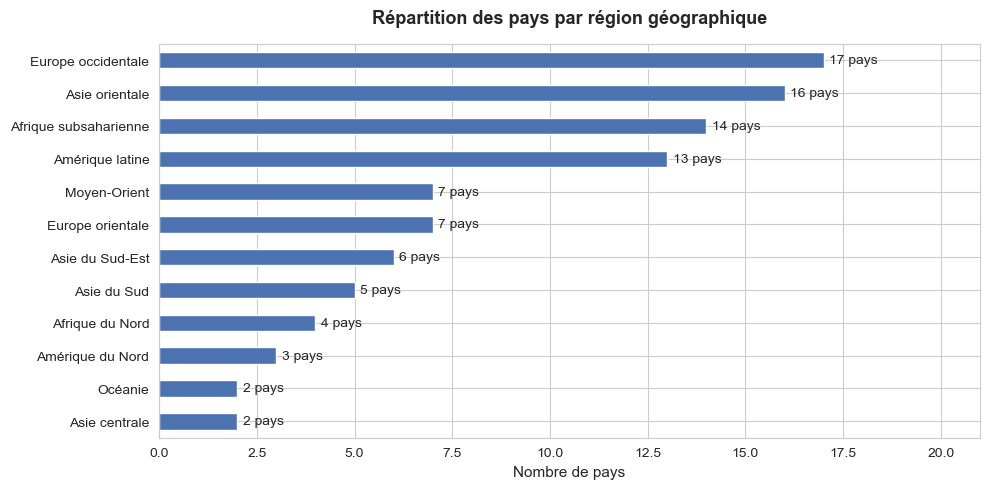

```python
# Répartition par région
repartition = df.groupby('region')['pays'].count().sort_values(ascending=True)

fig, ax = plt.subplots(figsize=(10, 5))
bars = repartition.plot(kind='barh', ax=ax, color='#4C72B0', edgecolor='white')
ax.bar_label(ax.containers[0], fmt='%d pays', padding=4, fontsize=10)
ax.set_title('Répartition des pays par région géographique', fontweight='bold', pad=15)
ax.set_xlabel('Nombre de pays')
ax.set_ylabel('')
ax.set_xlim(0, repartition.max() + 4)
plt.tight_layout()
plt.savefig('outputs/02_repartition_regions.png', dpi=150, bbox_inches='tight')
plt.show()
```

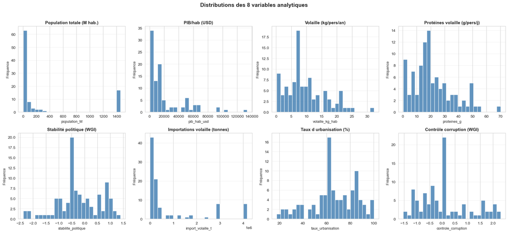

```python
# Distributions des 8 variables analytiques
variables = {
    'population_M':         'Population totale (M hab.)',
    'pib_hab_usd':          'PIB/hab (USD)',
    'volaille_kg_hab':      'Volaille (kg/pers/an)',
    'proteines_g':          'Protéines volaille (g/pers/j)',
    'stabilite_politique':  'Stabilité politique (WGI)',
    'import_volaille_t':    'Importations volaille (tonnes)',
    'taux_urbanisation':    'Taux d urbanisation (%)',
    'controle_corruption':  'Contrôle corruption (WGI)',
}

fig, axes = plt.subplots(2, 4, figsize=(18, 8))
axes = axes.flatten()

for ax, (col, titre) in zip(axes, variables.items()):
    ax.hist(df[col].dropna(), bins=25, color='steelblue', edgecolor='white', alpha=0.85)
    ax.set_title(titre, fontsize=11, fontweight='bold')
    ax.set_xlabel(col, fontsize=9)
    ax.set_ylabel('Fréquence', fontsize=9)
    ax.grid(axis='y', alpha=0.3)

plt.suptitle('Distributions des 8 variables analytiques', fontsize=14, fontweight='bold', y=1.02)
plt.tight_layout()
plt.savefig('outputs/05_distributions_8vars.png', dpi=150, bbox_inches='tight')
plt.show()
```

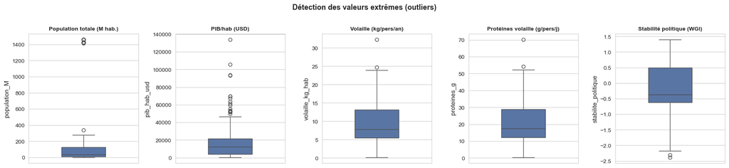

[output not shown]

```python
# Détection des valeurs extrêmes (outliers) par boxplot
fig, axes = plt.subplots(1, 5, figsize=(18, 4))
for ax, (col, label) in zip(axes, variables.items()):
    sns.boxplot(y=df[col], ax=ax, color='#4C72B0', width=0.4)
    ax.set_title(label, fontsize=10, fontweight='bold')
    ax.set_xlabel('')

plt.suptitle('Détection des valeurs extrêmes (outliers)',
             fontsize=13, fontweight='bold', y=1.02)
plt.tight_layout()
plt.savefig('outputs/04_boxplots_outliers.png', dpi=150, bbox_inches='tight')
plt.show()

# Identifier les pays outliers sur la population
q99_pop = df['population_M'].quantile(0.99)
print(f'Pays avec population > {q99_pop:.0f} M :')
print(df[df['population_M'] > q99_pop][['pays','population_M']].to_string(index=False))
print('\n→ Ces pays (Chine, Inde) sont des outliers naturels conservés dans l\'analyse.')
```

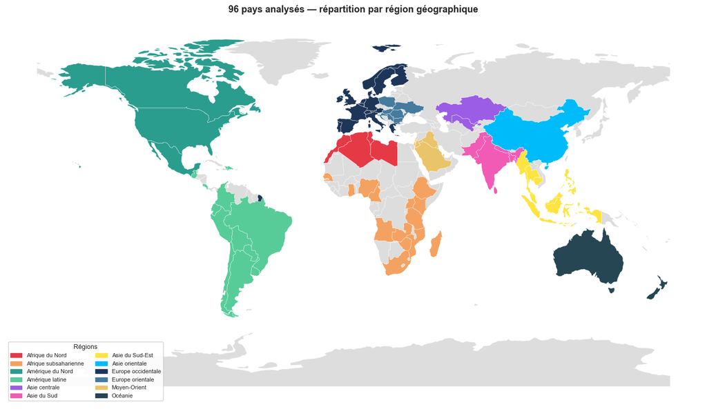

```python
import geopandas as gpd
import matplotlib.pyplot as plt
import matplotlib.patches as mpatches

# Téléchargement direct Natural Earth (fonctionne toujours)
url = "https://naciscdn.org/naturalearth/110m/cultural/ne_110m_admin_0_countries.zip"
world = gpd.read_file(url)

# Table de correspondance
pays_to_geo = {
    'United States':  'United States of America',
    'Czech Republic': 'Czechia',
    'Bolivia':        'Bolivia',
    'Venezuela':      'Venezuela',
    'Tanzania':       'Tanzania',
    'Russia':         'Russia',
    'South Korea':    'South Korea',
    'Iran':           'Iran',
    'Syria':          'Syria',
    'Vietnam':        'Vietnam',
    'Dominican Republic': 'Dominican Rep.',
}

df_map = df.copy()
df_map['pays_geo'] = df_map['pays'].replace(pays_to_geo)

# Fusion avec le fond de carte
world_merged = world.merge(
    df_map[['pays_geo', 'region']],
    left_on='NAME', right_on='pays_geo',
    how='left'
)

# Palette 12 régions
palette_regions = {
    'Afrique du Nord':        '#E63946',
    'Afrique subsaharienne':  '#F4A261',
    'Amérique du Nord':       '#2A9D8F',
    'Amérique latine':        '#57CC99',
    'Asie centrale':          '#9B5DE5',
    'Asie du Sud':            '#F15BB5',
    'Asie du Sud-Est':        '#FEE440',
    'Asie orientale':         '#00BBF9',
    'Europe occidentale':     '#1D3557',
    'Europe orientale':       '#457B9D',
    'Moyen-Orient':           '#E9C46A',
    'Océanie':                '#264653',
}

fig, ax = plt.subplots(figsize=(16, 8))

# Pays non analysés en gris clair
world_merged[world_merged['region'].isna()].plot(
    ax=ax, color='#DDDDDD', edgecolor='white', linewidth=0.3
)

# Pays analysés colorés par région
for region, color in palette_regions.items():
    subset = world_merged[world_merged['region'] == region]
    if len(subset) > 0:
        subset.plot(ax=ax, color=color, edgecolor='white', linewidth=0.3)

# Légende
patches = [mpatches.Patch(color=c, label=r) for r, c in palette_regions.items()]
ax.legend(handles=patches, loc='lower left', fontsize=8,
          framealpha=0.9, ncol=2, title='Régions', title_fontsize=9)

ax.set_title('96 pays analysés — répartition par région géographique',
             fontsize=13, fontweight='bold', pad=12)
ax.axis('off')
plt.tight_layout()
plt.savefig('outputs/00_carte_regions.png', dpi=150, bbox_inches='tight')
plt.show()

# Diagnostic : pays non matchés
non_matches = df_map[~df_map['pays_geo'].isin(world['NAME'].values)]['pays_geo'].tolist()
if non_matches:
    print(f"⚠️ Pays non matchés ({len(non_matches)}) :")
    for p in non_matches:
        print(f"  - {p}")
```

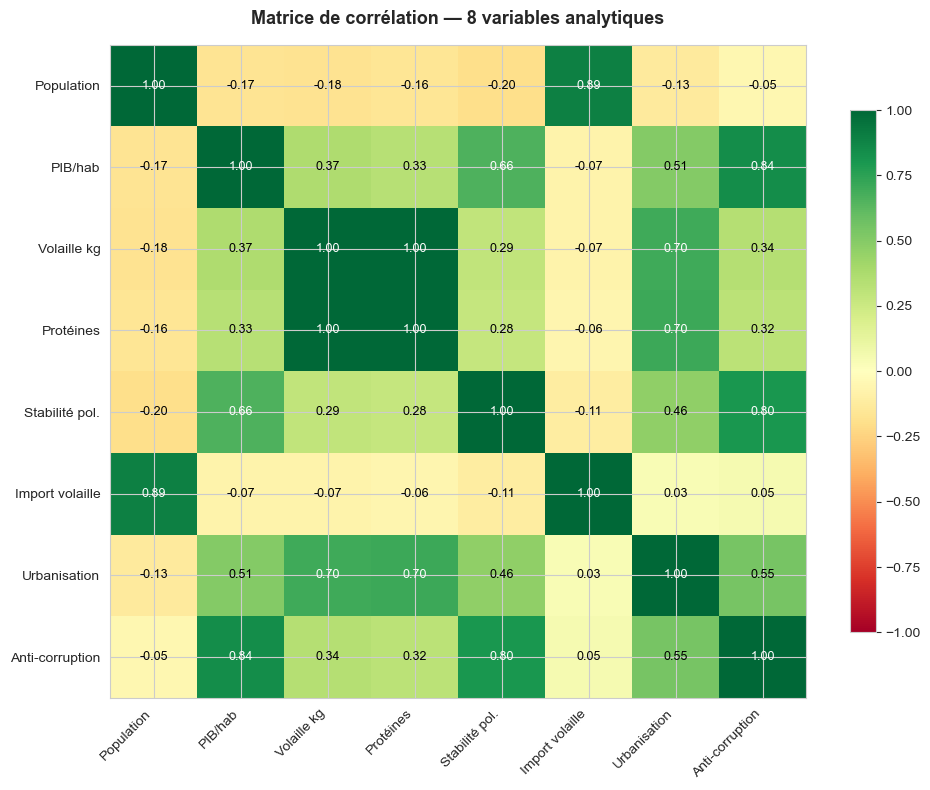

```
Corrélations notables :
  population_M × import_volaille_t : 0.891
  pib_hab_usd × stabilite_politique : 0.660
  pib_hab_usd × taux_urbanisation : 0.506
  pib_hab_usd × controle_corruption : 0.841
  volaille_kg_hab × proteines_g : 0.996
  volaille_kg_hab × taux_urbanisation : 0.695
  proteines_g × taux_urbanisation : 0.703
  stabilite_politique × controle_corruption : 0.802
  taux_urbanisation × controle_corruption : 0.545
```

```python
# Matrice de corrélation entre les 8 variables analytiques
cols_num = ['population_M', 'pib_hab_usd', 'volaille_kg_hab', 'proteines_g',
            'stabilite_politique', 'import_volaille_t', 'taux_urbanisation',
            'controle_corruption']

corr_matrix = df[cols_num].corr()

fig, ax = plt.subplots(figsize=(10, 8))
im = ax.imshow(corr_matrix, cmap='RdYlGn', vmin=-1, vmax=1, aspect='auto')
plt.colorbar(im, ax=ax, shrink=0.8)

labels = ['Population', 'PIB/hab', 'Volaille kg', 'Protéines',
          'Stabilité pol.', 'Import volaille', 'Urbanisation', 'Anti-corruption']
ax.set_xticks(range(len(labels)))
ax.set_yticks(range(len(labels)))
ax.set_xticklabels(labels, rotation=45, ha='right', fontsize=10)
ax.set_yticklabels(labels, fontsize=10)

for i in range(len(labels)):
    for j in range(len(labels)):
        val = corr_matrix.iloc[i, j]
        color = 'white' if abs(val) > 0.6 else 'black'
        ax.text(j, i, f'{val:.2f}', ha='center', va='center', fontsize=9, color=color)

ax.set_title('Matrice de corrélation — 8 variables analytiques',
             fontsize=13, fontweight='bold', pad=15)
plt.tight_layout()
plt.savefig('outputs/05b_correlation_8vars.png', dpi=150, bbox_inches='tight')
plt.show()

print('Corrélations notables :')
for i in range(len(cols_num)):
    for j in range(i+1, len(cols_num)):
        val = corr_matrix.iloc[i, j]
        if abs(val) > 0.5:
            print(f'  {cols_num[i]} × {cols_num[j]} : {val:.3f}')
```

## 7. Sauvegarde du dataset final

Le dataset nettoyé est sauvegardé au format CSV. Il constituera le point d'entrée du **Notebook 2** (ACP + Clustering).

```python
# Sauvegarde
chemin = 'D:/dataAnalyst/Projet11/travail/donnees_fao__clean.csv'
df_save = df.drop(columns=['pays_fao'])  # on garde pays_fao dans le df mais on ne l'exporte pas
df_save.to_csv(chemin, index=False, encoding='utf-8')

print('=' * 60)
print('  DATASET FINAL SAUVEGARDE')
print('=' * 60)
print(f'  Fichier  : {chemin}')
print(f'  Pays     : {len(df_save)}')
print(f'  Regions  : {df_save["region"].nunique()}')
print(f'  Variables: {len(df_save.columns)}')
print(f'  Annee    : 2021')
print(f'  NaN      : {df_save.isnull().sum().sum()}')
print()
print('  Variables analytiques (8) :')
print('  - population_M        : Population totale (M hab.)     [PESTEL - Social]')
print('  - pib_hab_usd         : PIB par habitant (USD)         [PESTEL - Economique]')
print('  - volaille_kg_hab     : Dispo. volaille (kg/pers/an)   [PESTEL - Social]')
print('  - proteines_g         : Proteines volaille (g/j)       [PESTEL - Social]')
print('  - stabilite_politique : Stabilite WGI (-3 a +3)        [PESTEL - Politique]')
print('  - import_volaille_t   : Importations volaille (tonnes) [PESTEL - Economique]')
print('  - taux_urbanisation   : % population urbaine           [PESTEL - Social]')
print('  - controle_corruption : Anti-corruption WGI (-3 a +3)  [PESTEL - Legal]')
print()
print('  Pret pour le Notebook 2 - ACP & Clustering')

df_save.head(10)
```

[output not shown]

## 8. Synthèse de la préparation

[output not shown]

**Couverture PESTEL :**

| Dimension | Variable(s) | Source |
| --- | --- | --- |
| **P**olitique | stabilite_politique | Banque Mondiale WGI |
| **E**conomique | pib_hab_usd, import_volaille_t | FAOSTAT |
| **S**ocial | population_M, volaille_kg_hab, proteines_g, taux_urbanisation | FAOSTAT |
| **L**égal | controle_corruption | QoG Institute / BM WGI |

**Points d'attention pour l'ACP :**

- Les variables ont des échelles très différentes → **normalisation `StandardScaler` obligatoire**
- `volaille_kg_hab` et `proteines_g` sont très corrélées → l'ACP les regroupera sur un même axe
- `stabilite_politique` et `controle_corruption` peuvent être corrélées (deux indices WGI)
- `import_volaille_t` est très asymétrique (Chine, Japon) → surveiller l'impact sur les axes ACP
- Chine et Inde sont des outliers en population → surveiller leur impact sur les clusters